# Bike-Share Analysis

Taofeeqoh

2023-09-25

# About the Case Study

This case study is a cap stone project in partial fulfillment of Google Data Analytics Certificate. The dataset was provided by Cyclistic Marketing Team. Cyclistic is a bike-share program that features more than 5,800 bicycles and 600 docking stations. Cyclistic sets itself apart by also offering reclining bikes, hand tricycles, and cargo bikes, making bike-share more inclusive to people with disabilities and riders who can’t use a standard two-wheeled bike. The majority of riders opt for traditional bikes; about 8% of riders use the assistive options. Cyclistic users are more likely to ride for leisure, but about 30% use them to commute to work each day

This case study involves analyzing 12-months period Cyclistics historical bike trip dataset which range between jan 2022 and dec 2022 to identify trends for the marketing analyst team in the direction of understanding how casual riders and annual members use Cyclistics bike differently, so as to make recommendations backed up with compelling data insights and professional data visualization which will be used to design a new marketing strategy with the aim of maximizing the number of annual memberships for the company’s future success.

# Documentation of the Analysis Process

*Data collection* Data cleaning *Data manipulation* Data aggregation *Data visualization* Draw conclusion and share suggestions

I used R for this project because it allows me to collect the dataset together as it is in different file, clean, manipulate, transform, visualize and create report in one environment. It also allows me to include my code in the report.

The necessary packages needed to work with the data in this environment has been loaded. the packages include; tidyverse,dplyr,lubridate,ggplot2.

```r
library(tidyverse)
```

```r
library(dplyr)
library(ggplot2)
library(stats)
library(lubridate)
library(readr)
library(tinytex)
```

# Data Collection

## Importing and appending the datasets

- The datasets are in csv format, hence, i use read_csv() function to import the dataset and append using rbind() function

```r
df1 <- read_csv("202201-divvy-tripdata.csv")
df2 <- read_csv("202202-divvy-tripdata.csv")
df3 <- read_csv("202203-divvy-tripdata.csv")
df4 <- read_csv("202204-divvy-tripdata.csv")
df5 <- read_csv("202205-divvy-tripdata.csv")
df6 <- read_csv("202206-divvy-tripdata.csv")
df7 <- read_csv("202207-divvy-tripdata.csv")
df8 <- read_csv("202208-divvy-tripdata.csv")
df9 <- read_csv("202209-divvy-tripdata.csv")
df10 <- read_csv("202210-divvy-tripdata.csv")
df11 <- read_csv("202211-divvy-tripdata.csv")
df12 <- read_csv("202212-divvy-tripdata.csv")
```

*combining the dataset by appending the rows together using rbind() function

```r
divvy_tripdata_2022 <- rbind(df1,df2,df3,df4,df5,df6,df7,df8,df9,df10,df11,df12)
```

- inspecting the combined dataset using head() function, summary()function

```r
head(divvy_tripdata_2022)
```

```
## # A tibble: 6 × 13
##   ride_id          rideable_type started_at          ended_at
##   <chr>            <chr>         <dttm>              <dttm>
## 1 C2F7DD78E82EC875 electric_bike 2022-01-13 11:59:47 2022-01-13 12:02:44
## 2 A6CF8980A652D272 electric_bike 2022-01-10 08:41:56 2022-01-10 08:46:17
## 3 BD0F91DFF741C66D classic_bike  2022-01-25 04:53:40 2022-01-25 04:58:01
## 4 CBB80ED419105406 classic_bike  2022-01-04 00:18:04 2022-01-04 00:33:00
## 5 DDC963BFDDA51EEA classic_bike  2022-01-20 01:31:10 2022-01-20 01:37:12
## 6 A39C6F6CC0586C0B classic_bike  2022-01-11 18:48:09 2022-01-11 18:51:31
## # ℹ 9 more variables: start_station_name <chr>, start_station_id <chr>,
## #   end_station_name <chr>, end_station_id <chr>, start_lat <dbl>,
## #   start_lng <dbl>, end_lat <dbl>, end_lng <dbl>, member_casual <chr>
```

```r
summary(divvy_tripdata_2022)
```

```
##    ride_id          rideable_type        started_at
##  Length:5667717     Length:5667717     Min.   :2022-01-01 00:00:05.00
##  Class :character   Class :character   1st Qu.:2022-05-28 19:21:05.00
##  Mode  :character   Mode  :character   Median :2022-07-22 15:03:59.00
##                                        Mean   :2022-07-20 07:21:18.74
##                                        3rd Qu.:2022-09-16 07:21:29.00
##                                        Max.   :2022-12-31 23:59:26.00
##
##     ended_at                      start_station_name start_station_id
##  Min.   :2022-01-01 00:01:48.00   Length:5667717     Length:5667717
##  1st Qu.:2022-05-28 19:43:07.00   Class :character   Class :character
##  Median :2022-07-22 15:24:44.00   Mode  :character   Mode  :character
##  Mean   :2022-07-20 07:40:45.33
##  3rd Qu.:2022-09-16 07:39:03.00
##  Max.   :2023-01-02 04:56:45.00
##
##  end_station_name   end_station_id       start_lat       start_lng
##  Length:5667717     Length:5667717     Min.   :41.64   Min.   :-87.84
##  Class :character   Class :character   1st Qu.:41.88   1st Qu.:-87.66
##  Mode  :character   Mode  :character   Median :41.90   Median :-87.64
##                                        Mean   :41.90   Mean   :-87.65
##                                        3rd Qu.:41.93   3rd Qu.:-87.63
##                                        Max.   :45.64   Max.   :-73.80
##
##     end_lat         end_lng       member_casual
##  Min.   : 0.00   Min.   :-88.14   Length:5667717
##  1st Qu.:41.88   1st Qu.:-87.66   Class :character
##  Median :41.90   Median :-87.64   Mode  :character
##  Mean   :41.90   Mean   :-87.65
##  3rd Qu.:41.93   3rd Qu.:-87.63
##  Max.   :42.37   Max.   :  0.00
##  NA's   :5858    NA's   :5858
```

# Data Cleaning

- There is a need to remove columns that are not needed in our analysis

```r
trip_data <- divvy_tripdata_2022 %>%
  select(-start_station_name,-start_station_id,-start_lat,-start_lng,-end_station_name,-end_station_id,-end_lat,-end_lng)

trip_data
```

```
## # A tibble: 5,667,717 × 5
##    ride_id   rideable_type started_at          ended_at            member_casual
##    <chr>     <chr>         <dttm>              <dttm>              <chr>
##  1 C2F7DD78… electric_bike 2022-01-13 11:59:47 2022-01-13 12:02:44 casual
##  2 A6CF8980… electric_bike 2022-01-10 08:41:56 2022-01-10 08:46:17 casual
##  3 BD0F91DF… classic_bike  2022-01-25 04:53:40 2022-01-25 04:58:01 member
##  4 CBB80ED4… classic_bike  2022-01-04 00:18:04 2022-01-04 00:33:00 casual
##  5 DDC963BF… classic_bike  2022-01-20 01:31:10 2022-01-20 01:37:12 member
##  6 A39C6F6C… classic_bike  2022-01-11 18:48:09 2022-01-11 18:51:31 member
##  7 BDC4AB63… classic_bike  2022-01-30 18:32:52 2022-01-30 18:49:26 member
##  8 81751A31… classic_bike  2022-01-22 12:20:02 2022-01-22 12:32:06 member
##  9 154222B8… electric_bike 2022-01-17 07:34:41 2022-01-17 08:00:08 member
## 10 72DC25B2… classic_bike  2022-01-28 15:27:53 2022-01-28 15:35:16 member
## # ℹ 5,667,707 more rows
```

- Renaming the started_at,ended_at and member_casual column

```r
trip_data <- trip_data %>%
  rename(bicycle_type = rideable_type, start_time = started_at, end_time = ended_at, subscribers = member_casual)
```

```r
glimpse(trip_data)
```

```
## Rows: 5,667,717
## Columns: 5
## $ ride_id      <chr> "C2F7DD78E82EC875", "A6CF8980A652D272", "BD0F91DFF741C66D…
## $ bicycle_type <chr> "electric_bike", "electric_bike", "classic_bike", "classi…
## $ start_time   <dttm> 2022-01-13 11:59:47, 2022-01-10 08:41:56, 2022-01-25 04:…
## $ end_time     <dttm> 2022-01-13 12:02:44, 2022-01-10 08:46:17, 2022-01-25 04:…
## $ subscribers  <chr> "casual", "casual", "member", "casual", "member", "member…
```

# Data Manipulation

*For easy analysis there is a need to extract the month, day and hours of the day from the start_time column

```r
trip_data <- trip_data %>%
  mutate(months = month(start_time, label = TRUE))

trip_data <- trip_data %>%
  mutate(days_of_the_week = weekdays(start_time))

trip_data <- trip_data %>%
  mutate(hours_of_the_day = hour(start_time))
```

# Data Aggregation

The data is now ready for analysis after cleaning and removing unwanted columns. The insights will be obtained by performing data aggregation on the dataset. The following are the insights that will be identified.

*Trip counts for the whole year* Trip counts by different subscribers *Trip counts by distinct bicycle* Aggregate count of rides taken by various subscribers using distinct bicycles *Total trip counts on a monthly basis* Aggregate Counts of trips made by different subscribers on a monthly basis *Trip counts per day* Total number of trips made by different subscribers on a daily basis *Aggregate trip counts made by different subscriber during each hour of the day* Average Duration of trips for different subscribers *Average Duration of trips on a daily basis* Average Duration of trips for different subscriber on a daily basis *Average Duration of trips on a monthly basis* Average Duration of trips for different subscriber on a monthly basis *Average Duration of rides with distinct bicycle* Average Duration of trips for different subscriber with distinct bicycle

### Trip counts for the whole year

```r
total_trip <- trip_data %>% summarise( count = n())
total_trip
```

```
## # A tibble: 1 × 1
##     count
##     <int>
## 1 5667717
```

### Trip counts by different subscribers

```r
total_trip_by_subscribers <- trip_data %>% count(subscribers)

total_trip_by_subscribers
```

```
## # A tibble: 2 × 2
##   subscribers       n
##   <chr>         <int>
## 1 casual      2322032
## 2 member      3345685
```

The number of annual subscriber have a high trip count of 3,345,685 compared to 2,322,032 trip counts of the casual rider. which shows that there are more trip counts from the anual subscriber than the casual riders.

### Trip count by distinct bicycle

```r
total_trip_with_bicycle_type <- trip_data %>% count(bicycle_type)

total_trip_with_bicycle_type
```

```
## # A tibble: 3 × 2
##   bicycle_type        n
##   <chr>           <int>
## 1 classic_bike  2601214
## 2 docked_bike    177474
## 3 electric_bike 2889029
```

electric bike is the most used bike with the ride of 2,889,029, which is followed by the classic bike with ride of 2,601,214 counts and the least used bike is the docked bike with ride of 177,474 counts.

### Aggregate count of rides taken by various subscribers using distinct bicycles

```r
subscriber_with_bicycle_type <- trip_data %>% group_by(subscribers) %>% count(bicycle_type)

subscriber_with_bicycle_type
```

```
## # A tibble: 5 × 3
## # Groups:   subscribers [2]
##   subscribers bicycle_type        n
##   <chr>       <chr>           <int>
## 1 casual      classic_bike   891459
## 2 casual      docked_bike    177474
## 3 casual      electric_bike 1253099
## 4 member      classic_bike  1709755
## 5 member      electric_bike 1635930
```

The annual subscribers does not use docked bike, only the electric bike and the classic bike are used by the annual subscribers while the casual riders are the make use of all bike type

### Total trip counts on a monthly basis

```r
total_trip_by_months <- trip_data %>% count(months)

total_trip_by_months
```

```
## # A tibble: 12 × 2
##    months      n
##    <ord>   <int>
##  1 Jan    103770
##  2 Feb    115609
##  3 Mar    284042
##  4 Apr    371249
##  5 May    634858
##  6 Jun    769204
##  7 Jul    823488
##  8 Aug    785932
##  9 Sep    701339
## 10 Oct    558685
## 11 Nov    337735
## 12 Dec    181806
```

There is a spike in the number of trips from june to september. To investigate the cause of the high increase in the trip count, we will obtain the counts of trips made by different subscribers on a monthly basis

### Aggregate Counts of trips made by different subscribers on a monthly basis

```r
subscriber_by_month <- trip_data %>% group_by(subscribers) %>% count(months) %>% arrange(months)

subscriber_by_month
```

```
## # A tibble: 24 × 3
## # Groups:   subscribers [2]
##    subscribers months      n
##    <chr>       <ord>   <int>
##  1 casual      Jan     18520
##  2 member      Jan     85250
##  3 casual      Feb     21416
##  4 member      Feb     94193
##  5 casual      Mar     89882
##  6 member      Mar    194160
##  7 casual      Apr    126417
##  8 member      Apr    244832
##  9 casual      May    280415
## 10 member      May    354443
## # ℹ 14 more rows
```

There is high counts of trip by annual member from june to september

### Trip counts per day

```r
total_trip_by_days <- trip_data %>% count(days_of_the_week)

total_trip_by_days
```

```
## # A tibble: 7 × 2
##   days_of_the_week      n
##   <chr>             <int>
## 1 Friday           801787
## 2 Monday           751014
## 3 Saturday         916471
## 4 Sunday           776259
## 5 Thursday         841591
## 6 Tuesday          782372
## 7 Wednesday        798223
```

There is high number of trip counts thursday, friday and saturday.

###Total number of trips made by different subscribers on a daily basis

```r
subscriber_by_days <- trip_data %>% group_by(subscribers) %>% count(days_of_the_week) %>% arrange(days_of_the_week)

subscriber_by_days
```

```
## # A tibble: 14 × 3
## # Groups:   subscribers [2]
##    subscribers days_of_the_week      n
##    <chr>       <chr>             <int>
##  1 casual      Friday           334701
##  2 member      Friday           467086
##  3 casual      Monday           277675
##  4 member      Monday           473339
##  5 casual      Saturday         473190
##  6 member      Saturday         443281
##  7 casual      Sunday           389036
##  8 member      Sunday           387223
##  9 casual      Thursday         309330
## 10 member      Thursday         532261
## 11 casual      Tuesday          263746
## 12 member      Tuesday          518626
## 13 casual      Wednesday        274354
## 14 member      Wednesday        523869
```

### Aggregate trip counts made by different subscriber during each hour of the day

```r
subscriber_by_hours <- trip_data %>% group_by(subscribers) %>% count(hours_of_the_day) %>% arrange(hours_of_the_day)

subscriber_by_hours
```

```
## # A tibble: 48 × 3
## # Groups:   subscribers [2]
##    subscribers hours_of_the_day     n
##    <chr>                  <int> <int>
##  1 casual                     0 46477
##  2 member                     0 36074
##  3 casual                     1 30162
##  4 member                     1 22178
##  5 casual                     2 18686
##  6 member                     2 12894
##  7 casual                     3 11112
##  8 member                     3  8055
##  9 casual                     4  7619
## 10 member                     4  8942
## # ℹ 38 more rows
```

### Aggregate trip counts during each hour of the day

```r
trip_count_by_hours <- trip_data %>% count(hours_of_the_day) %>% arrange(hours_of_the_day)

trip_count_by_hours
```

```
## # A tibble: 24 × 2
##    hours_of_the_day      n
##               <int>  <int>
##  1                0  82551
##  2                1  52340
##  3                2  31580
##  4                3  19167
##  5                4  16561
##  6                5  44719
##  7                6 120681
##  8                7 224031
##  9                8 274293
## 10                9 216137
## # ℹ 14 more rows
```

There is a high counts of trip between the hours of 16 to 18 (i.e between 4pm to 6pm)

### Average Duration of trips for different subscribers(minutes)

```r
avg_duration_by_subscribers <- trip_data %>% group_by(subscribers) %>%
  summarise(avg_trip_length = mean(minute(seconds_to_period(end_time-start_time))))

avg_duration_by_subscribers
```

```
## # A tibble: 2 × 2
##   subscribers avg_trip_length
##   <chr>                 <dbl>
## 1 casual                 15.7
## 2 member                 11.1
```

### Average Duration of trips on a daily basis

```r
avg_daily_trip_length <- trip_data %>% group_by(days_of_the_week) %>%
  summarise(avg_trip_length = mean(minute(seconds_to_period(end_time-start_time))))

avg_daily_trip_length
```

```
## # A tibble: 7 × 2
##   days_of_the_week avg_trip_length
##   <chr>                      <dbl>
## 1 Friday                      12.7
## 2 Monday                      12.6
## 3 Saturday                    14.8
## 4 Sunday                      14.7
## 5 Thursday                    12.2
## 6 Tuesday                     11.9
## 7 Wednesday                   11.9
```

### Average Duration of trips for different subscriber on a daily basis

```r
avg_daily_trip_length_by_subscribers <- trip_data %>% group_by(subscribers,days_of_the_week) %>%
  summarise(avg_trip_length =mean(minute(seconds_to_period(end_time-start_time)))) %>%
    arrange(days_of_the_week)
avg_daily_trip_length_by_subscribers
```

```
## # A tibble: 14 × 3
## # Groups:   subscribers [2]
##    subscribers days_of_the_week avg_trip_length
##    <chr>       <chr>                      <dbl>
##  1 casual      Friday                      15.2
##  2 member      Friday                      11.0
##  3 casual      Monday                      15.8
##  4 member      Monday                      10.8
##  5 casual      Saturday                    17.2
##  6 member      Saturday                    12.3
##  7 casual      Sunday                      17.2
##  8 member      Sunday                      12.2
##  9 casual      Thursday                    14.5
## 10 member      Thursday                    10.8
## 11 casual      Tuesday                     14.4
## 12 member      Tuesday                     10.6
## 13 casual      Wednesday                   14.2
## 14 member      Wednesday                   10.7
```

There is high duration of rides by the casual riders on Saturday and Sunday with average trip length of 17.2mins both.

### Average Duration of trips on a monthly basis

```r
avg_monthly_trip_length <- trip_data %>% group_by(months) %>%
  summarise(avg_trip_length = mean(minute(seconds_to_period(end_time-start_time)))) %>%
  arrange(months)

avg_monthly_trip_length
```

```
## # A tibble: 12 × 2
##    months avg_trip_length
##    <ord>            <dbl>
##  1 Jan              10.2
##  2 Feb              10.5
##  3 Mar              12.4
##  4 Apr              12.3
##  5 May              14.4
##  6 Jun              14.4
##  7 Jul              14.3
##  8 Aug              13.6
##  9 Sep              12.8
## 10 Oct              11.6
## 11 Nov              10.4
## 12 Dec               9.42
```

### Average Duration of trips for different subscriber on a monthly basis

```r
avg_monthly_trip_length_by_subscribers <- trip_data %>% group_by(subscribers,months) %>%
  summarise(avg_trip_length =mean(minute(seconds_to_period(end_time-start_time)))) %>%
    arrange(months)
avg_monthly_trip_length_by_subscribers
```

```
## # A tibble: 24 × 3
## # Groups:   subscribers [2]
##    subscribers months avg_trip_length
##    <chr>       <ord>            <dbl>
##  1 casual      Jan              12.8
##  2 member      Jan               9.62
##  3 casual      Feb              13.8
##  4 member      Feb               9.72
##  5 casual      Mar              16.8
##  6 member      Mar              10.4
##  7 casual      Apr              16.5
##  8 member      Apr              10.2
##  9 casual      May              17.5
## 10 member      May              11.9
## # ℹ 14 more rows
```

### Average Duration of trips during each hour of the day

```r
avg_hourly_trip_length <- trip_data %>% group_by(hours_of_the_day) %>%
  summarise(avg_trip_length = mean(minute(seconds_to_period(end_time-start_time)))) %>%
  arrange(hours_of_the_day)

avg_hourly_trip_length
```

```
## # A tibble: 24 × 2
##    hours_of_the_day avg_trip_length
##               <int>           <dbl>
##  1                0           12.3
##  2                1           12.3
##  3                2           12.5
##  4                3           12.3
##  5                4           11.7
##  6                5            9.89
##  7                6           10.2
##  8                7           10.8
##  9                8           10.8
## 10                9           11.8
## # ℹ 14 more rows
```

### Average Duration of trips for different subscriber during each hour of the day

```r
avg_hourly_trip_length_by_subscribers <- trip_data %>% group_by(subscribers,hours_of_the_day) %>%
  summarise(avg_trip_length =mean(minute(seconds_to_period(end_time-start_time)))) %>%
    arrange(hours_of_the_day)
avg_hourly_trip_length_by_subscribers
```

```
## # A tibble: 48 × 3
## # Groups:   subscribers [2]
##    subscribers hours_of_the_day avg_trip_length
##    <chr>                  <int>           <dbl>
##  1 casual                     0            13.6
##  2 member                     0            10.6
##  3 casual                     1            13.6
##  4 member                     1            10.4
##  5 casual                     2            13.9
##  6 member                     2            10.5
##  7 casual                     3            13.6
##  8 member                     3            10.5
##  9 casual                     4            12.7
## 10 member                     4            10.9
## # ℹ 38 more rows
```

### Average Duration of rides made with distinct bicycle

```r
avg_trip_length_by_bicycle_type <- trip_data %>%
  group_by(bicycle_type) %>%
  summarise(avg_trip_length =mean(minute(seconds_to_period(end_time-start_time))))

avg_trip_length_by_bicycle_type
```

```
## # A tibble: 3 × 2
##   bicycle_type  avg_trip_length
##   <chr>                   <dbl>
## 1 classic_bike             13.7
## 2 docked_bike              23.9
## 3 electric_bike            11.7
```

### Average Duration of trips for different subscriber with distinct bicycle

```r
avg_trip_length_by_bicycle_subscriber <- trip_data %>%
  group_by(subscribers,bicycle_type) %>%
  summarise(avg_trip_length =mean(minute(seconds_to_period(end_time-start_time))))
avg_trip_length_by_bicycle_subscriber
```

```
## # A tibble: 5 × 3
## # Groups:   subscribers [2]
##   subscribers bicycle_type  avg_trip_length
##   <chr>       <chr>                   <dbl>
## 1 casual      classic_bike             17.1
## 2 casual      docked_bike              23.9
## 3 casual      electric_bike            13.6
## 4 member      classic_bike             11.9
## 5 member      electric_bike            10.3
```

# Data Visualization

Now is the moment to create visual representations that will help the team comprehend the insights derived from data cleaning, manipulation, and aggregation. These visuals will enable the team to make more informed decisions.

The following are the visuals that will be created;

```r
options(scipen=999)
```

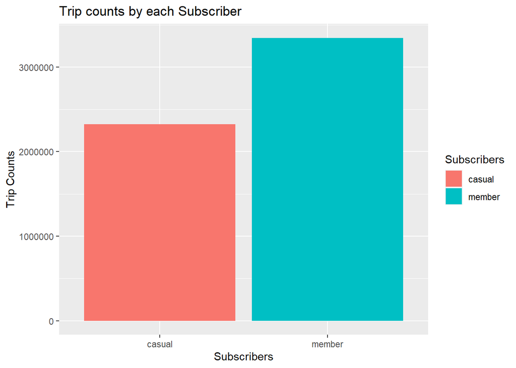

```r
ggplot(total_trip_by_subscribers) +
  geom_col(aes(x=subscribers,y=n, fill=subscribers)) +
  labs(x = "Subscribers", y = "Trip Counts", title = "Trip counts by each Subscriber", fill = "Subscribers")
```

The visual show that the annual subscribers have more trip compared with the casual rider

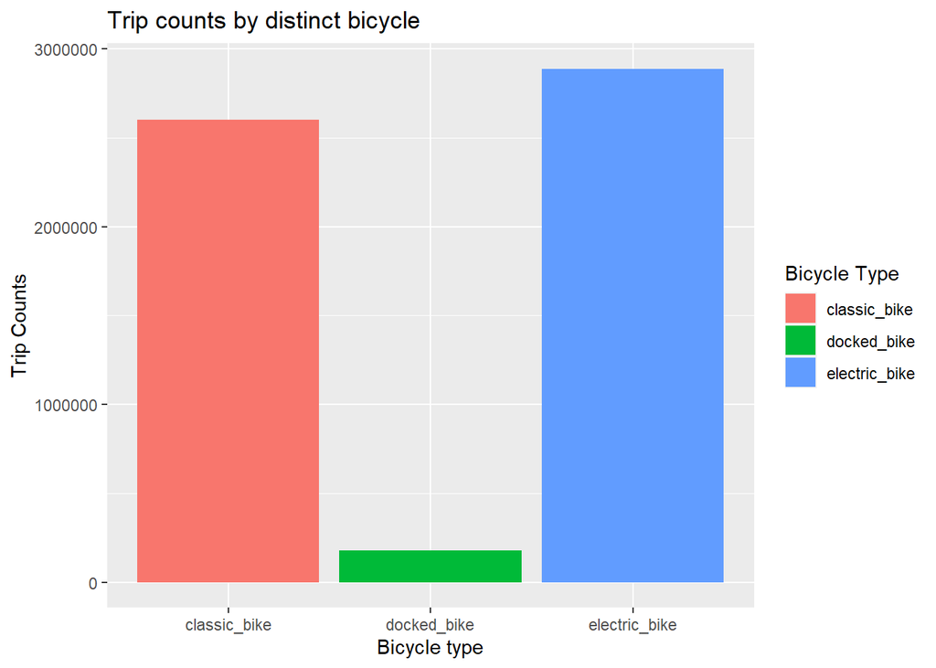

```r
ggplot(total_trip_with_bicycle_type) +
  geom_col(aes(x=bicycle_type,y=n, fill=bicycle_type)) +
  labs(x = "Bicycle type", y = "Trip Counts", title = "Trip counts by distinct bicycle", fill = "Bicycle Type")
```

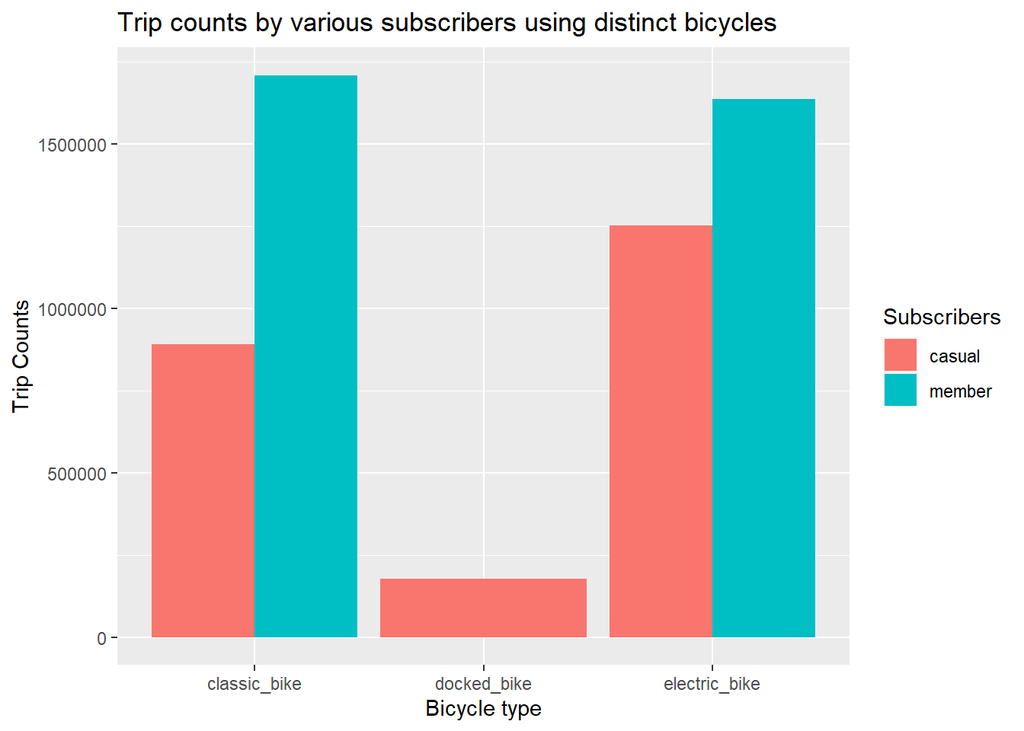

```r
ggplot(subscriber_with_bicycle_type) +
  geom_col(aes(x=bicycle_type,y=n, fill=subscribers), position = "dodge") +
  labs(x = "Bicycle type", y = "Trip Counts", title = "Trip counts by various subscribers using distinct bicycles", fill = "Subscribers")
```

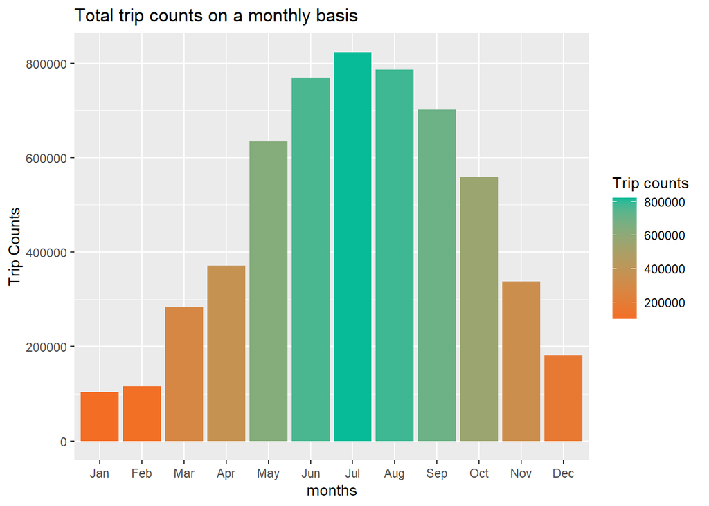

```r
ggplot(total_trip_by_months) +
  geom_col(aes(x=months,y=n, fill=n)) +
  labs(x = "months", y = "Trip Counts", title = "Total trip counts on a monthly basis", fill = "Trip counts ") +
  scale_fill_gradient(low="#f46d24", high="#07bb99")
```

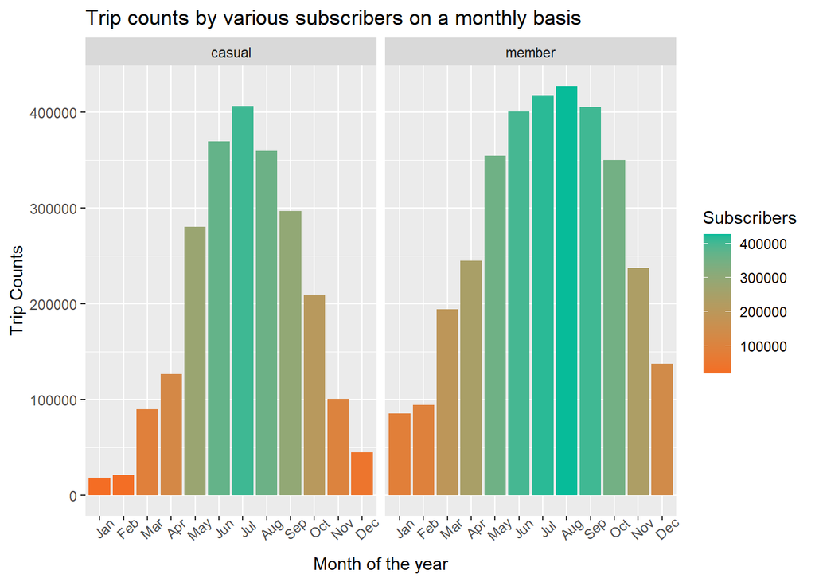

```r
ggplot(subscriber_by_month) +
  geom_col(aes(x=months,y=n, fill=n), position = "dodge") +
  labs(x = "Month of the year", y = "Trip Counts", title = "Trip counts by various subscribers on a monthly basis", fill = "Subscribers") +
  theme(axis.text.x = element_text(angle=42)) +
  facet_grid(~subscribers) +
  scale_fill_gradient(low="#f46d24", high="#07bb99")
```

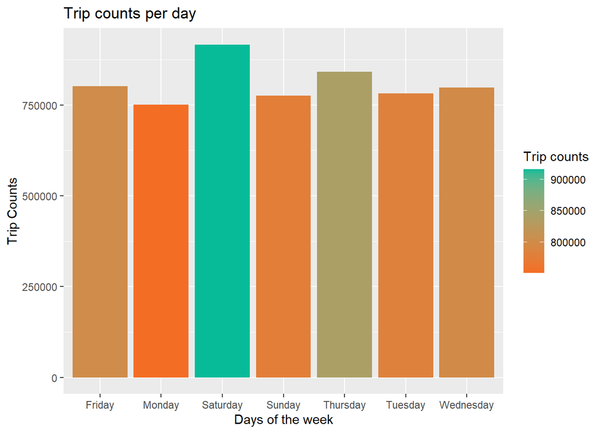

```r
ggplot(total_trip_by_days) +
  geom_col(aes(x=days_of_the_week,y=n, fill=n)) +
  labs(x = "Days of the week", y = "Trip Counts", title = "Trip counts per day", fill = "Trip counts ") +
  scale_fill_gradient(low="#f46d24", high="#07bb99")
```

Total number of trips made by different subscribers on a daily basis

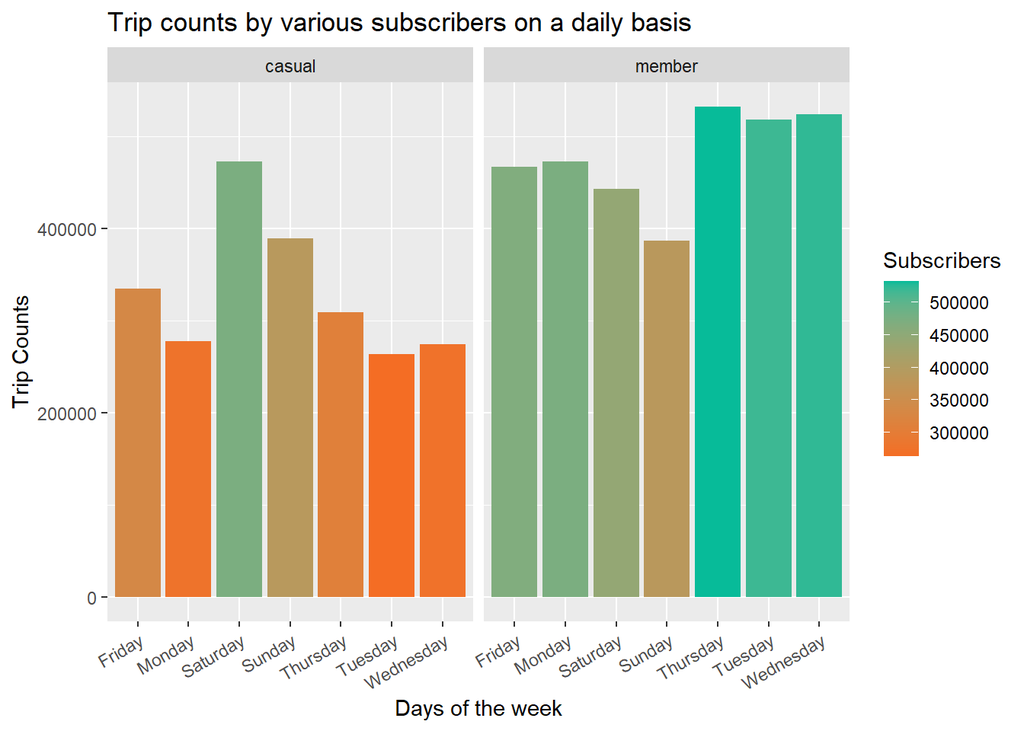

```r
ggplot(subscriber_by_days) +
  geom_col(aes(x=days_of_the_week,y=n, fill=n), position = "dodge") +
  labs(x = "Days of the week", y = "Trip Counts", title = "Trip counts by various subscribers on a daily basis", fill = "Subscribers") +
  theme(axis.text.x = element_text(angle=30,hjust = 1)) +
  facet_grid(~subscribers) +
  scale_fill_gradient(low="#f46d24", high="#07bb99")
```

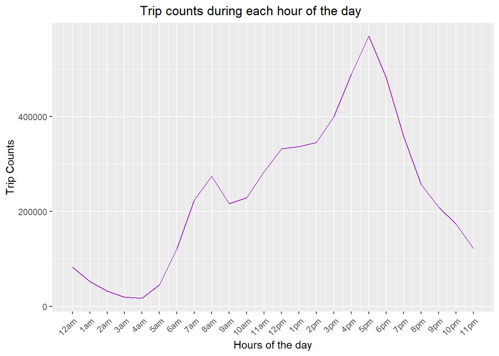

```r
ggplot(trip_count_by_hours) +
  geom_line(aes(x=hours_of_the_day,y=n), color= "#9d19c0") +
  labs(x = "Hours of the day", y = "Trip Counts", title = "Trip counts during each hour of the day") +
  scale_x_continuous(breaks = c(0:23), labels=c("12am","1am","2am","3am","4am","5am","6am","7am","8am","9am","10am","11am","12pm","1pm","2pm","3pm","4pm","5pm","6pm","7pm","8pm","9pm","10pm","11pm")) +
  theme(axis.text.x = element_text(angle=45,hjust = 1), plot.title = element_text(hjust = 0.4))
```

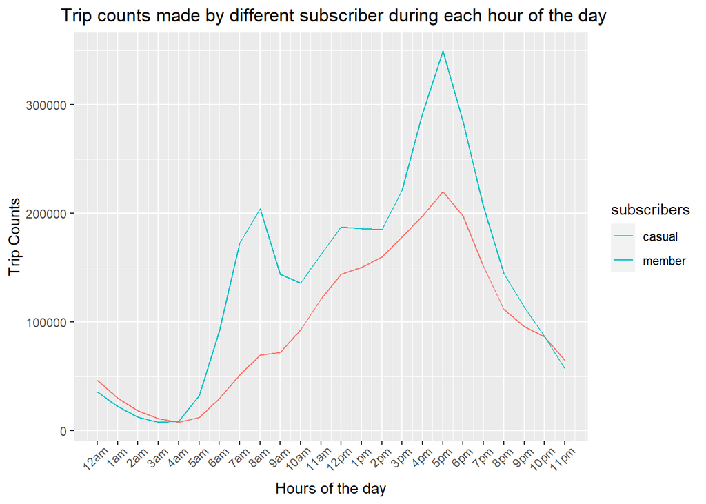

```r
ggplot(subscriber_by_hours) +
  geom_line(aes(x=hours_of_the_day,y=n, color= subscribers)) +
  labs(x = "Hours of the day", y = "Trip Counts", title = "Trip counts made by different subscriber during each hour of the day") +
  scale_x_continuous(breaks = c(0:23), labels=c("12am","1am","2am","3am","4am","5am","6am","7am","8am","9am","10am","11am","12pm","1pm","2pm","3pm","4pm","5pm","6pm","7pm","8pm","9pm","10pm","11pm")) +
  theme(axis.text.x = element_text(angle=45,hjust =0.8), plot.title = element_text(hjust = 0.4))
```

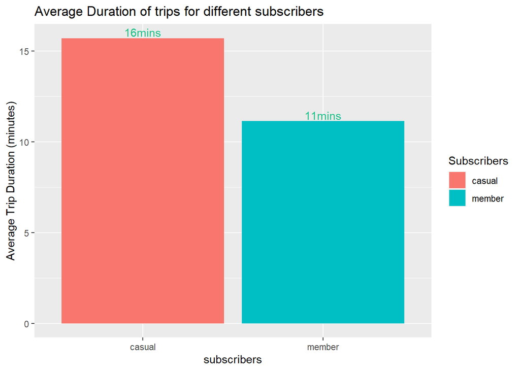

```r
ggplot(avg_duration_by_subscribers) +
  geom_col(aes(x=subscribers,y=avg_trip_length, fill=subscribers)) +
    geom_text(aes(x=subscribers,y=avg_trip_length,label = paste0( format(round(avg_trip_length,0)), "mins"),vjust=-0.2), color="#19c086") +
  labs(x = "subscribers", y = "Average Trip Duration (minutes)", title = "Average Duration of trips for different subscribers", fill = "Subscribers")
```

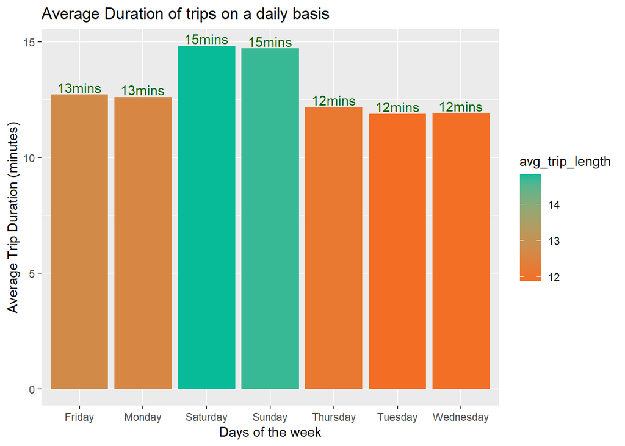

```r
ggplot(avg_daily_trip_length) +
  geom_col(aes(x=days_of_the_week,y=avg_trip_length, fill=avg_trip_length)) +
    geom_text(aes(x=days_of_the_week,y=avg_trip_length,label = paste0( format(round(avg_trip_length,0)), "mins"),vjust=-0.2), color="darkgreen") +
  labs(x = "Days of the week", y = "Average Trip Duration (minutes)", title = "Average Duration of trips on a daily basis") +
  scale_fill_gradient(low="#f46d24", high="#07bb99")
```

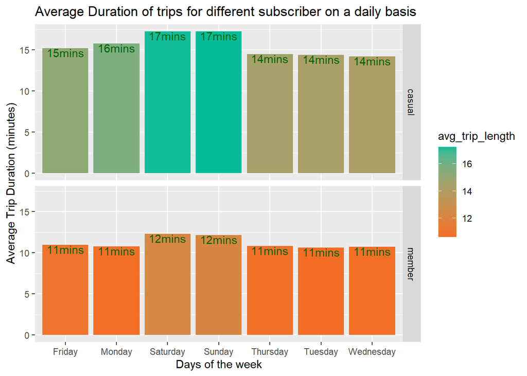

```r
ggplot(avg_daily_trip_length_by_subscribers) +
  geom_col(aes(x=days_of_the_week,y=avg_trip_length, fill=avg_trip_length), position = "dodge") +
    geom_text(aes(x=days_of_the_week,y=avg_trip_length,label = paste0( format(round(avg_trip_length,0)), "mins"),vjust=1), color="darkgreen") +
  labs(x = "Days of the week", y = "Average Trip Duration (minutes)", title = "Average Duration of trips for different subscriber on a daily basis") +
  facet_grid(rows = vars(subscribers)) +
  scale_fill_gradient(low="#f46d24", high="#07bb99")
```

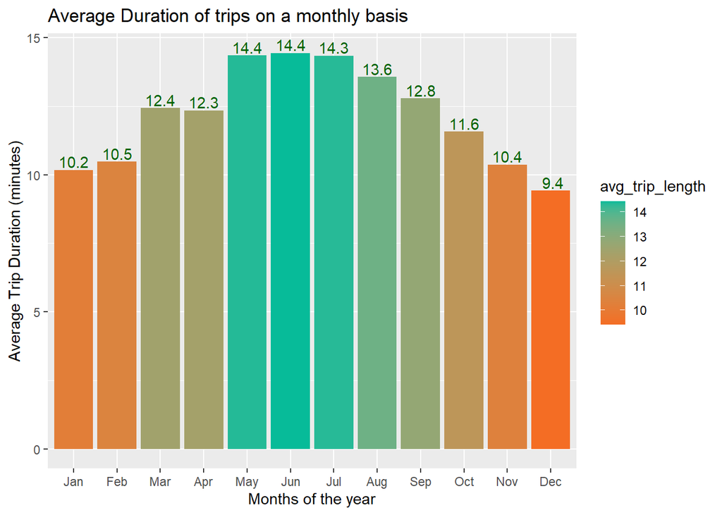

```r
ggplot(avg_monthly_trip_length) +
  geom_col(aes(x=months,y=avg_trip_length, fill=avg_trip_length)) +
    geom_text(aes(x=months,y=avg_trip_length,label = paste0( format(round(avg_trip_length,1))),vjust=-0.2), color="darkgreen") +
  labs(x = "Months of the year", y = "Average Trip Duration (minutes)", title = "Average Duration of trips on a monthly basis") +
  scale_fill_gradient(low="#f46d24", high="#07bb99")
```

Average Duration of trips for different subscriber on a monthly basis

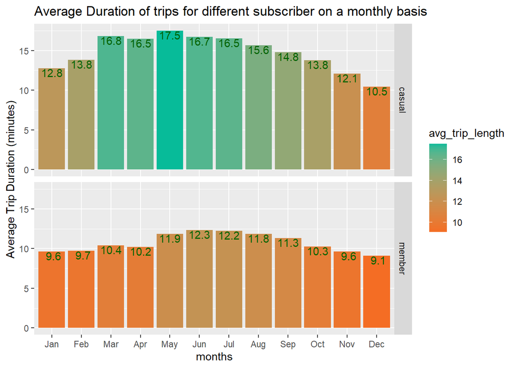

```r
ggplot(avg_monthly_trip_length_by_subscribers) +
  geom_col(aes(x=months,y=avg_trip_length, fill=avg_trip_length), position = "dodge") +
    geom_text(aes(x=months,y=avg_trip_length,label = paste0( format(round(avg_trip_length,1))),vjust=1), color="darkgreen") +
  labs(x = "months", y = "Average Trip Duration (minutes)", title = "Average Duration of trips for different subscriber on a monthly basis") +
  facet_grid(rows = vars(subscribers)) +
  scale_fill_gradient(low="#f46d24", high="#07bb99")
```

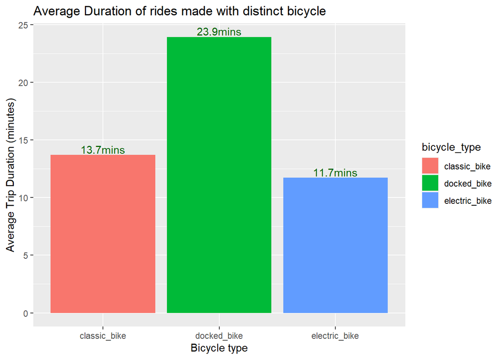

```r
ggplot(avg_trip_length_by_bicycle_type) +
  geom_col(aes(x=bicycle_type,y=avg_trip_length, fill=bicycle_type)) +
    geom_text(aes(x=bicycle_type,y=avg_trip_length,label = paste0( format(round(avg_trip_length,1)),"mins"),vjust=-0.2), color="darkgreen") +
  labs(x = "Bicycle type", y = "Average Trip Duration (minutes)", title = "Average Duration of rides made with distinct bicycle")
```

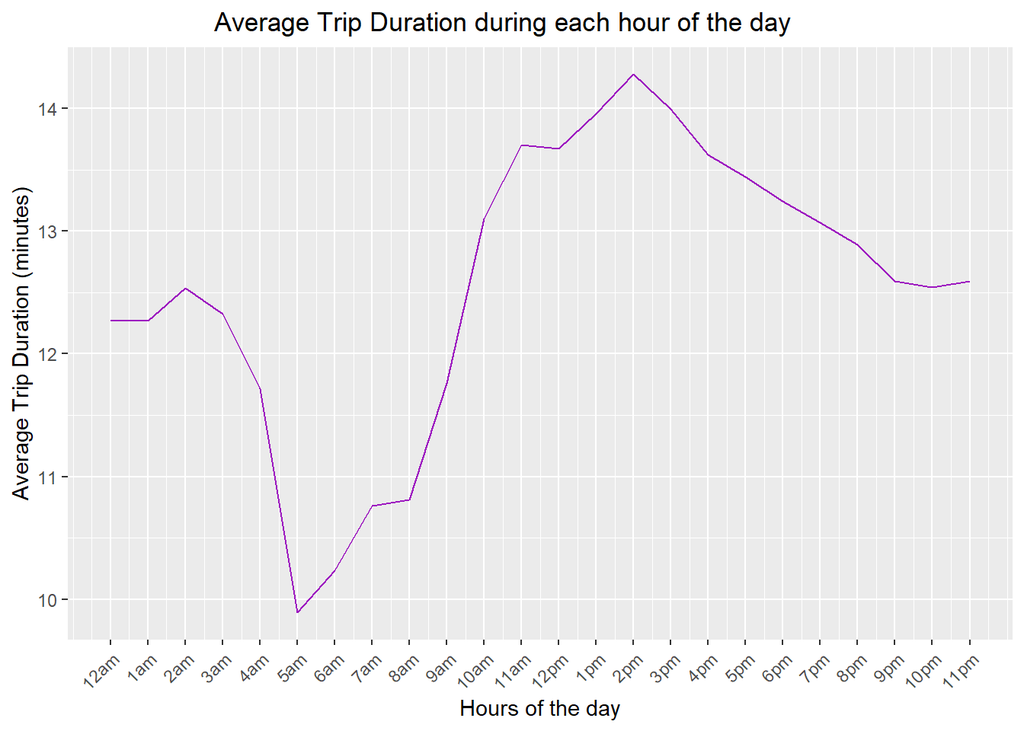

```r
ggplot(avg_hourly_trip_length) +
  geom_line(aes(x=hours_of_the_day,y=avg_trip_length), color= "#9d19c0") +
  labs(x = "Hours of the day", y = "Average Trip Duration (minutes)", title = "Average Trip Duration during each hour of the day") +
  scale_x_continuous(breaks = c(0:23), labels=c("12am","1am","2am","3am","4am","5am","6am","7am","8am","9am","10am","11am","12pm","1pm","2pm","3pm","4pm","5pm","6pm","7pm","8pm","9pm","10pm","11pm")) +
  theme(axis.text.x = element_text(angle=45,hjust = 1), plot.title = element_text(hjust = 0.4))
```

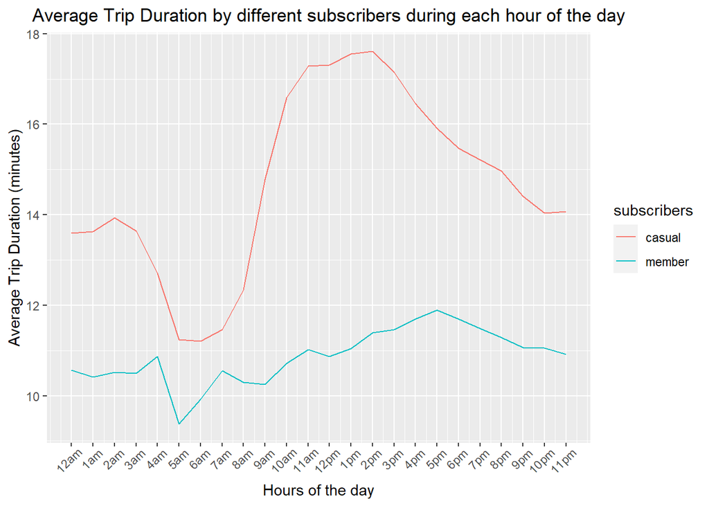

```r
ggplot(avg_hourly_trip_length_by_subscribers) +
  geom_line(aes(x=hours_of_the_day,y=avg_trip_length, color= subscribers)) +
  labs(x = "Hours of the day", y = "Average Trip Duration (minutes)", title = "Average Trip Duration by different subscribers during each hour of the day") +
  scale_x_continuous(breaks = c(0:23), labels=c("12am","1am","2am","3am","4am","5am","6am","7am","8am","9am","10am","11am","12pm","1pm","2pm","3pm","4pm","5pm","6pm","7pm","8pm","9pm","10pm","11pm")) +
  theme(axis.text.x = element_text(angle=45,hjust =0.8), plot.title = element_text(hjust = 0.3))
```

# Conclusions

# Suggestions